# FIT3152 Assignment 1

This is the R notebook for Assignment 1 for FIT3152, we are setting up the table as follows

Question 1(a)

```
## [1] 40000    54
```

Overall there are 40 thousand entries from people from all across the world that contributed towards this survey with 54 of unique identifiers.

```
## 'data.frame':    40000 obs. of  54 variables:
##  $ affAnx         : int  1 2 1 1 2 3 4 2 4 3 ...
##  $ affBor         : int  1 1 2 1 1 2 3 2 5 3 ...
##  $ affCalm        : int  4 4 3 3 5 2 2 3 5 3 ...
##  $ affContent     : int  4 2 3 3 4 2 3 3 5 3 ...
##  $ affDepr        : int  1 2 1 2 2 2 4 1 1 3 ...
##  $ affEnerg       : int  5 4 2 2 4 1 3 3 3 3 ...
##  $ affExc         : int  3 2 2 3 5 1 2 2 4 3 ...
##  $ affNerv        : int  1 2 1 2 3 2 5 2 3 3 ...
##  $ affExh         : int  1 1 1 2 2 3 4 1 2 3 ...
##  $ affInsp        : int  4 4 2 2 4 1 3 3 3 3 ...
##  $ affRel         : int  3 3 3 2 5 2 2 5 4 3 ...
##  $ PLRAC19        : int  7 4 3 3 1 5 5 2 5 3 ...
##  $ PLRAEco        : int  6 7 3 8 2 4 4 3 7 3 ...
##  $ disc01         : int  0 -1 0 0 2 1 1 0 2 0 ...
```

[output cut: 40 more lines]

Out of all the attributes from the data set, all of them are integers with a range of from negative-positive integers or 1-n positive integers. The only exception is coded_country with is based on a string of which the people are from.

```r
countries = unique(cvbase$coded_country)
length(countries)
```

```
## [1] 112
```

From the data set above, we are able to see that there are 112 unique countries in the dataset.

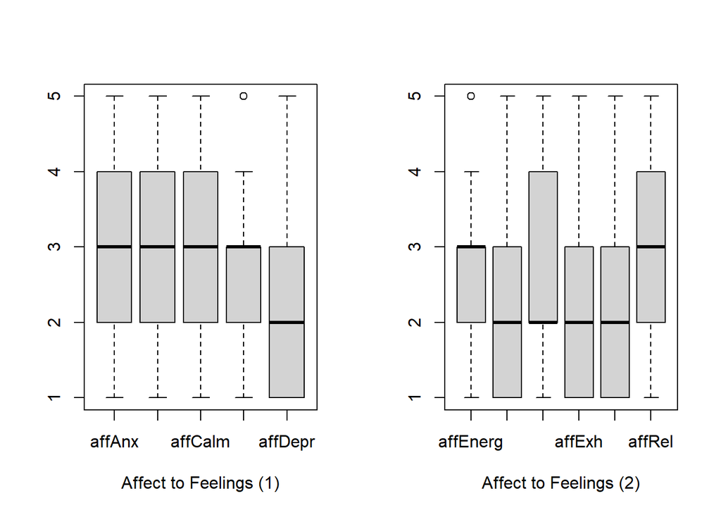

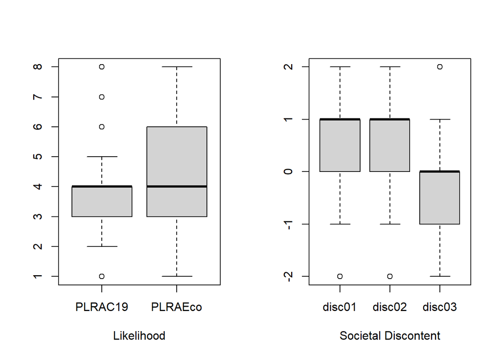

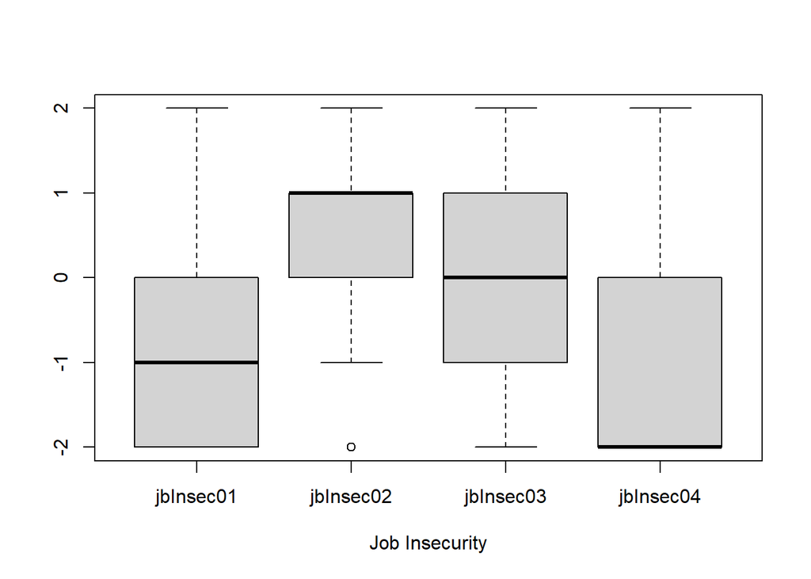

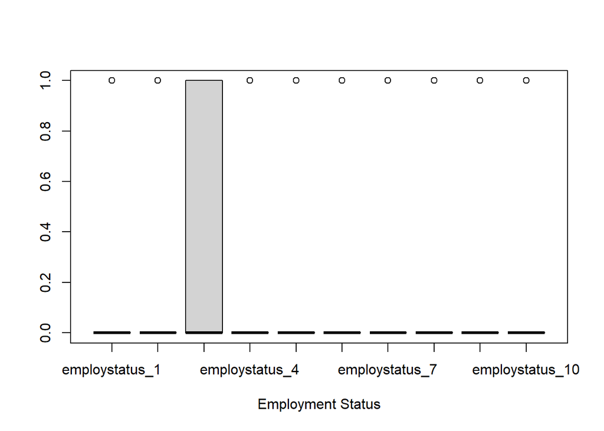

From the data set we are able to find the affects of the COVID-19 pandemic to the people who took the survey. These includes how it affected their feelings from a numerical value of 1 to 5 from 1 being Very slightly or not at all to 5 being Extremely, the likelihood that they think they will get the coronavirus and their personal situation getting worse due to the coronavirus on a 1 - 8 scale from 1 being exceptionally unlikely and 8 being already happened.

We also dive into societal discontent with society on a -2 - 2 scale, Job insecurity on a similar -2-2 scale. For Employment status we have a variety of different columns with 1 stating the status that they are in, and NA on all other columns otherwise. For this we will be changing the dataset of the employment status to be 1 if it is what best describes their employment status, and 0 instead of NA otherwise to help with further analysis of the data. This is because we will be omitting NA values from the dataset for processing later on.

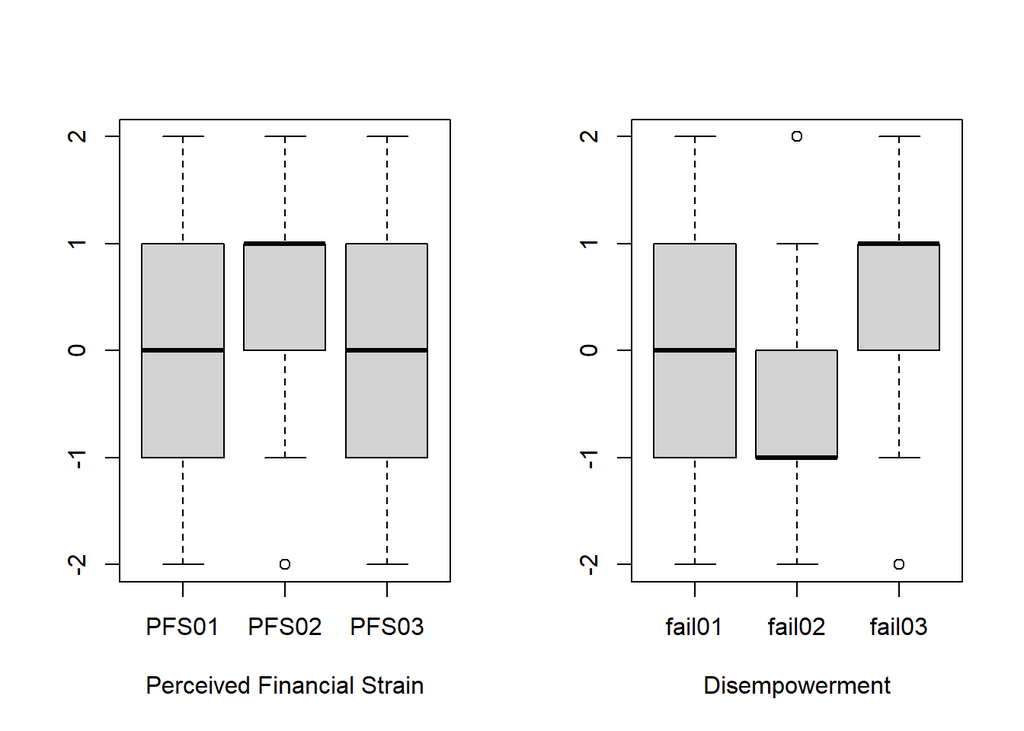

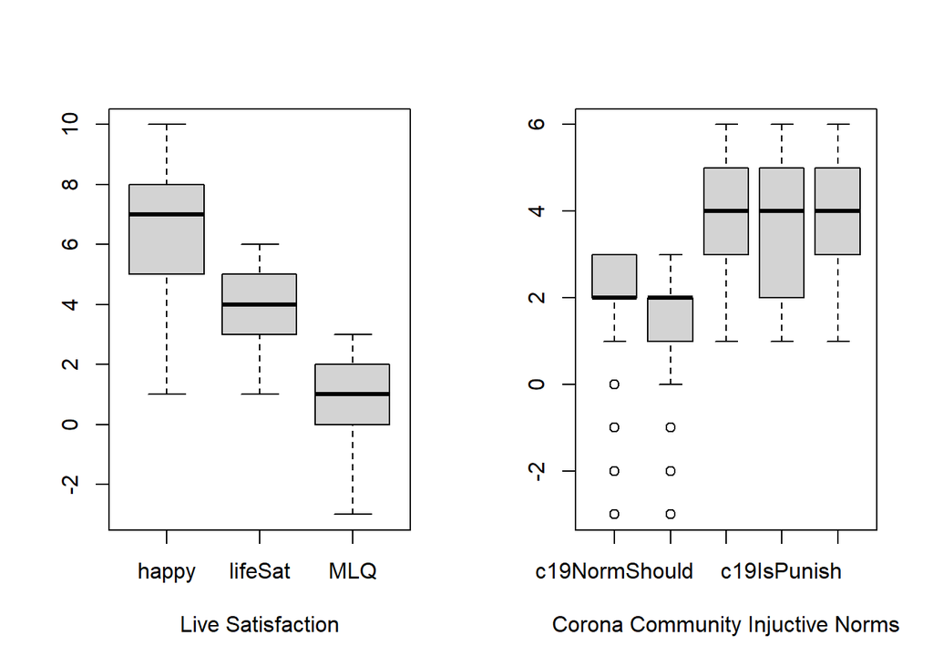

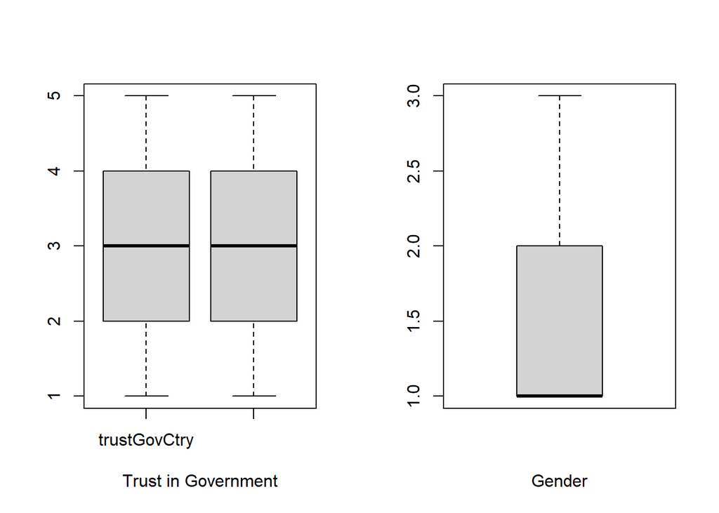

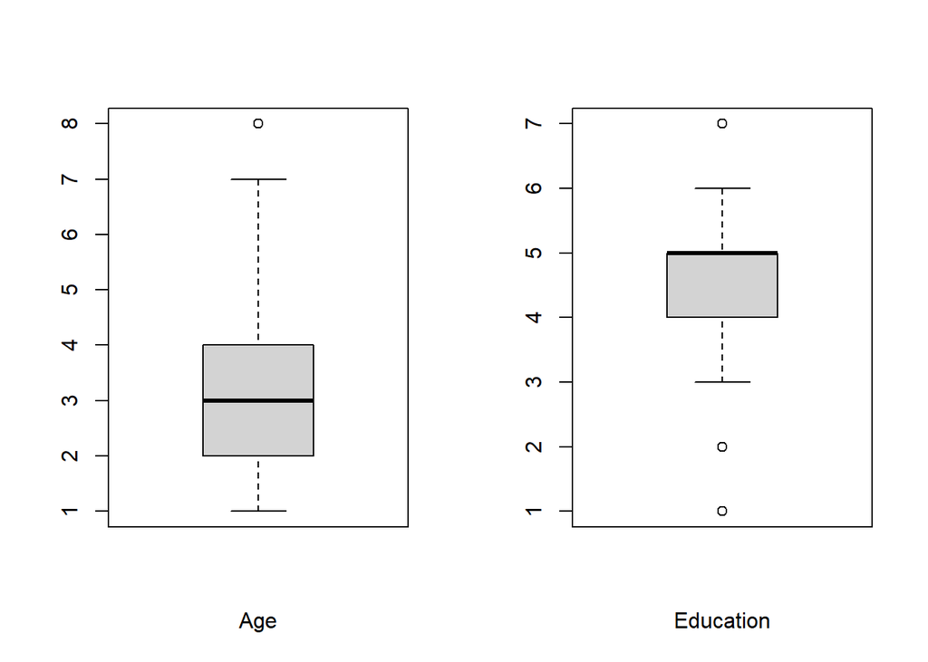

Next displays the person’s age gender with 1 being female, 2 being male and 3 being other. Next is the age group on a 1 to 8 scale with 1 being the young adult category (18-24) and 8 being the elderly category (85+) with each value being a range of 10 years with the 1st value being the only exception. Afterwards is Education on where we see a 1 to 7 scale with 1 being having primary education as the highest level of education received and 7 being getting a PhD degree,

For statistics we also kept track of gender, age, education and country. Lastly we ask them on their thoughts on Corona ProSocial Behaviour which includes the following details/columns:

“I am willing to:

• help others who suffer from coronavirus.” (c19ProSo01)

• make donations to help others that suffer from coronavirus.” (c19ProSo02)

• protect vulnerable groups from coronavirus even at my own expense.” (c19ProSo03)

• make personal sacrifices to prevent the spread of coronavirus.” (c19ProSo04)

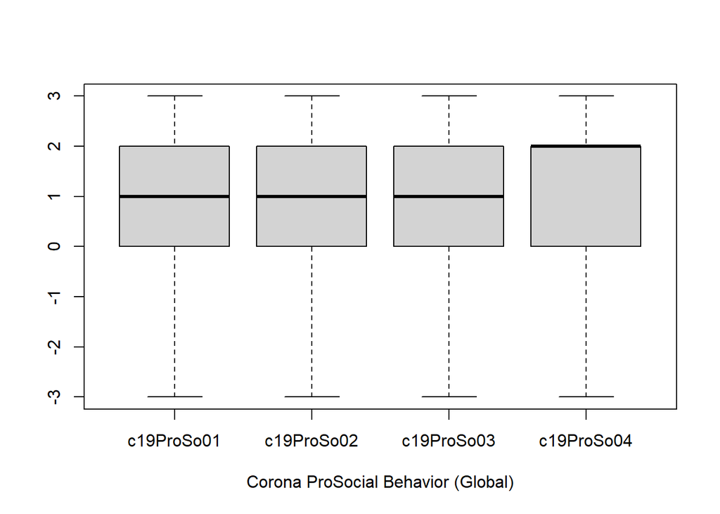

on a scale of -3-3. With -3 being Strongly disagree and 3 being Strongly agree.

For this analysis we will be diving deeper into country-level differences in predictors of pro-social behaviours.

Question 1(b)

Question 2(a)

Next we will be looking at the overall statistics for the pro-social behaviors of both Ukraine and Globally.

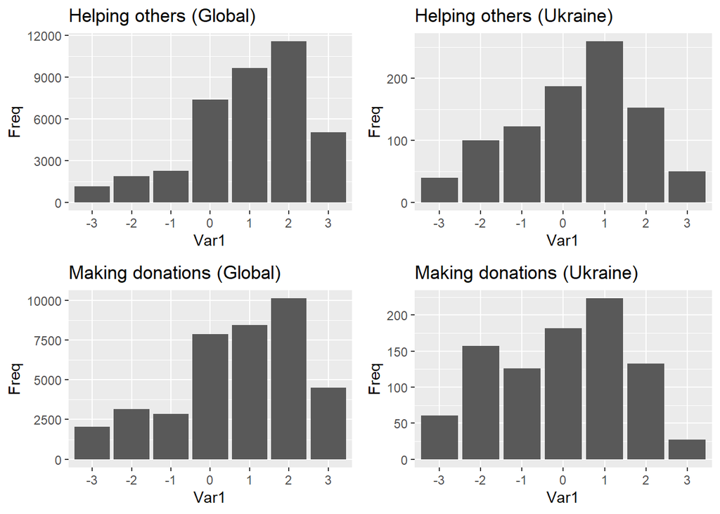

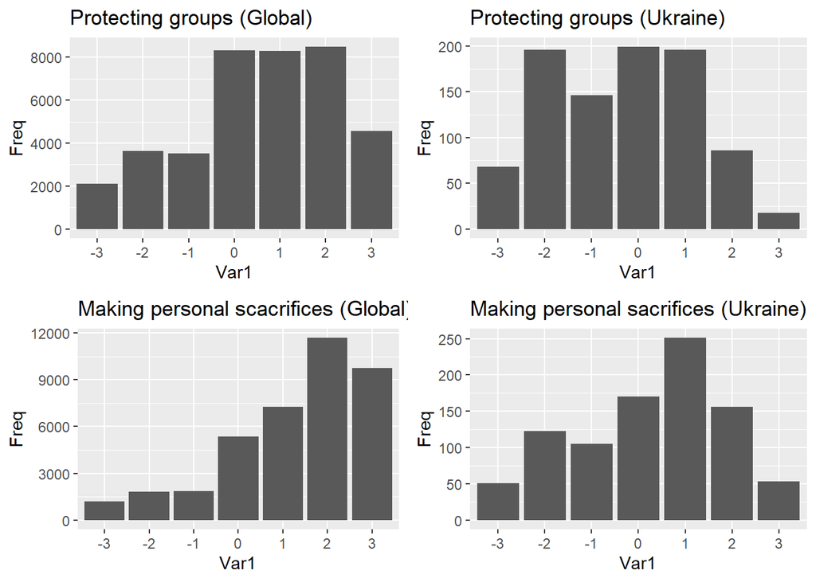

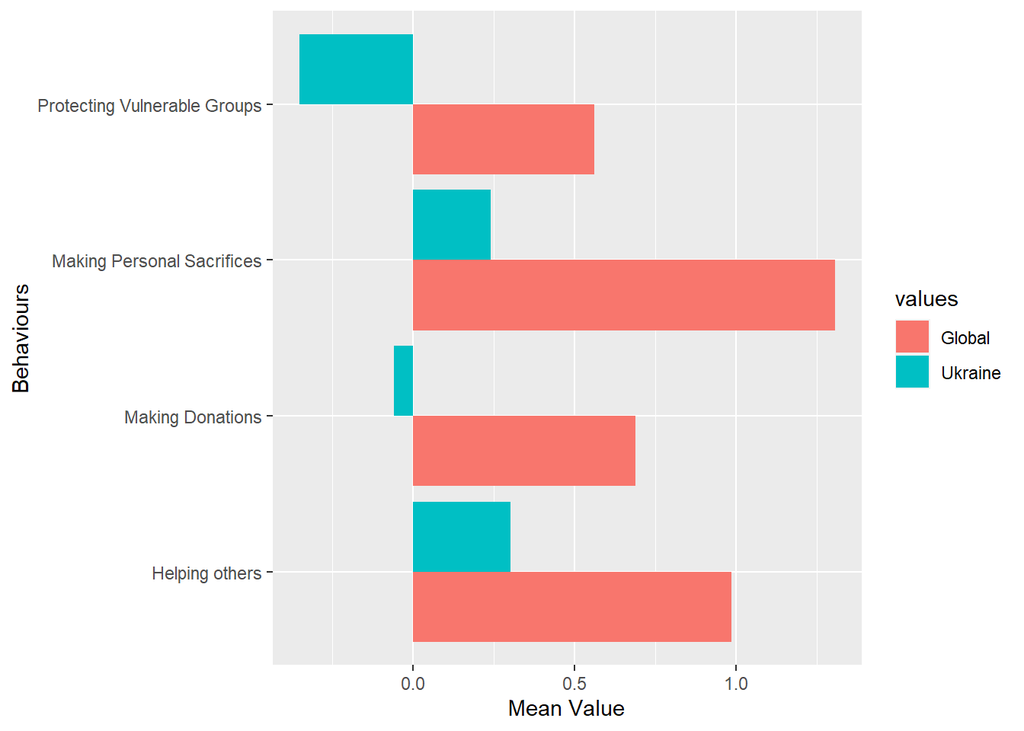

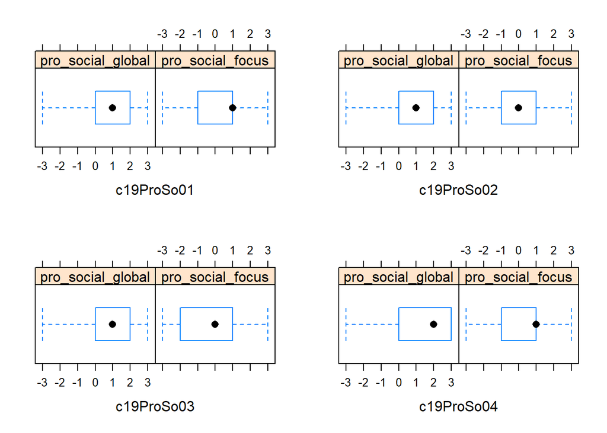

Based on the graphs above, we can clearly see that Ukraine on average has a less positive outlook towards their proSocial behaviour compared to the global average. Ukraine for all of the 4 pro-social behaviours chose that they are less likely to agree towards doing pro-social behaviors.

Based on the box and whisker plots here we can see that the first and third quartile of all the behaviors are lower than that of the global dataset.

Let’s compare on how COVID-19 has affected the feelings of the people that took the survey.

First off, we will be comparing the feelings of their emotions, and how their emotions have been impacted due to COVID-19,

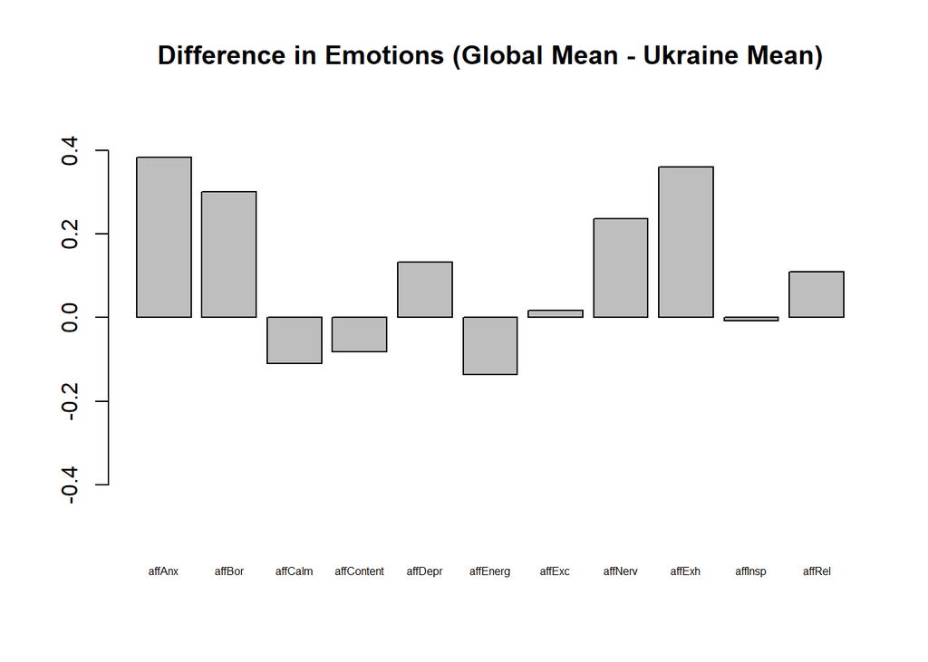

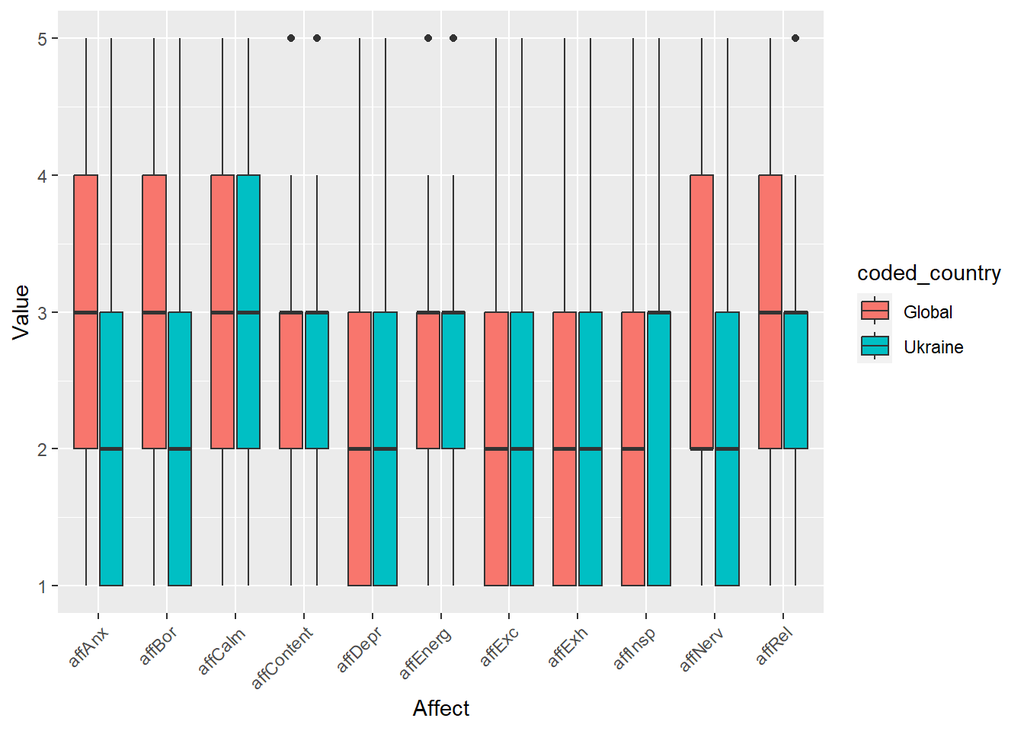

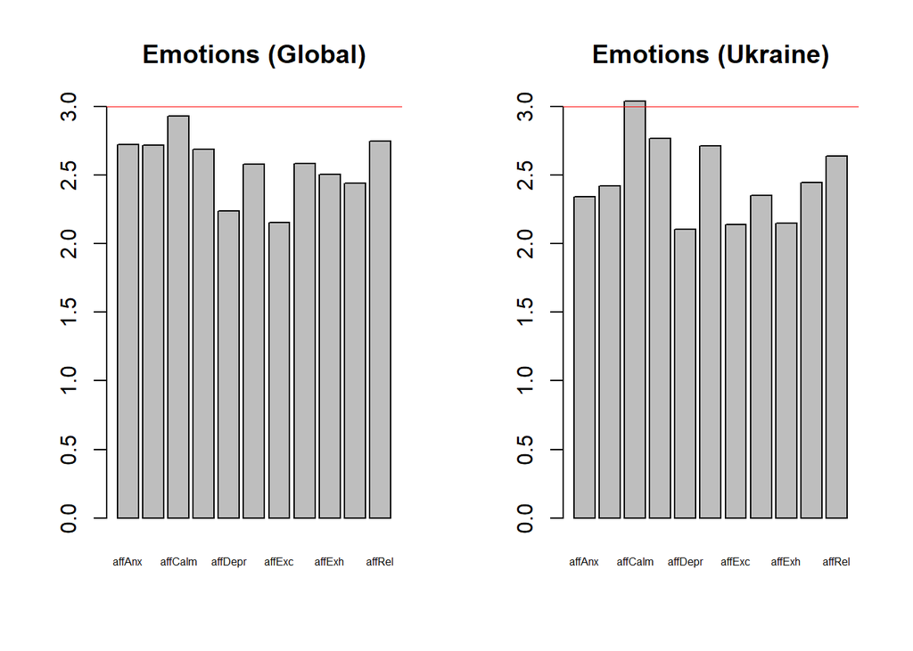

We can see that Ukrainians generally are more positive in their feelings on how COVID-19 has affected them than the mean, with the global mean usually higher on negative emotions such as being anxious, bored, depressed, nervous etc while being lower for positive emotions such as being calm, content and energetic. Relaxed is, however, the only outlier here. This is not a good indicator of overall pro_social behavior, as Ukraine has more positive outlook in their feelings compared to the global average, contradicting this with their Pro-social behaviour.

Let’s move on further into analyzing and comparing their satisfaction in life.

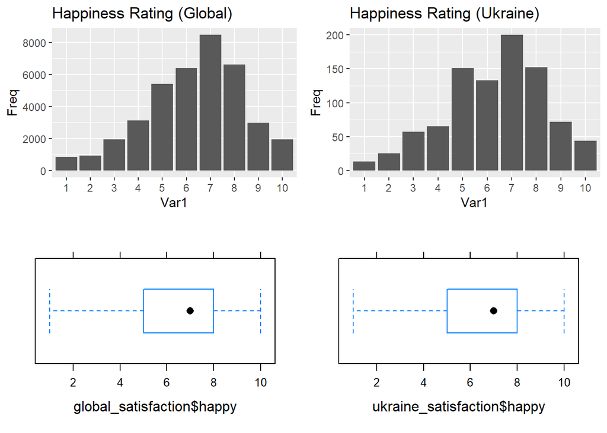

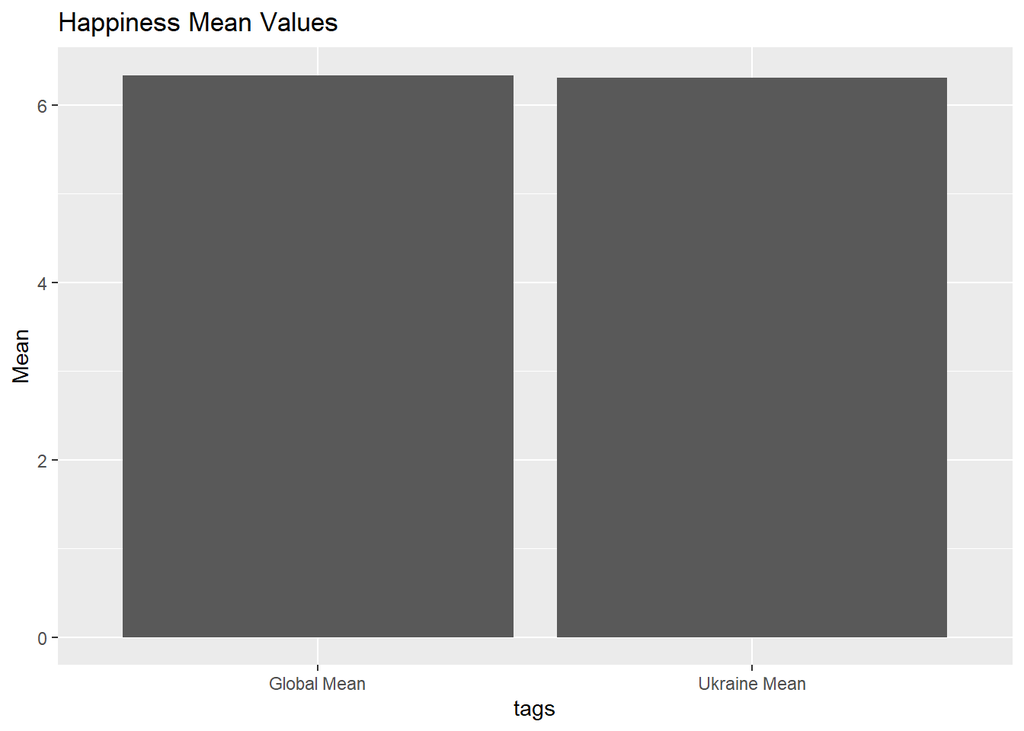

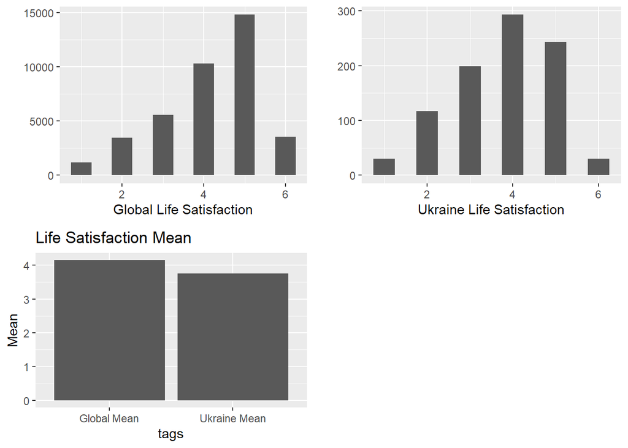

From here we can see that Ukrainians have a lower life satisfaction rating compared to the Global Mean while their happiness is slightly lower than the global average. Box and Whisker plots of the two attributes show the same values. This means that generally the Ukrainians are a bit less optimistic on how their life is going on so far as compared to everyone. This may be tied towards their financial situation or how COVID-19 has impacted them.

Let us look at their MLQ scores as well

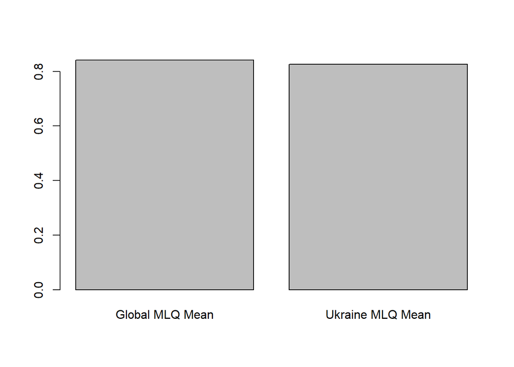

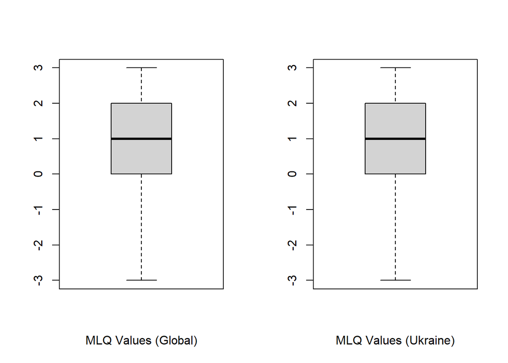

For MLQ the values are really similar, with the mean of Ukraine being slightly lower than that of the global average while the box and whisker plots show the same first quartile, third quartile and median.

Overall, Live Satisfaction seems relatively similar, now lets dive into what the people of Ukraine think the likelihood of getting COVID-19 and the likelihood that their personal situation will get worse due to the economic consequences of the coronavirus.

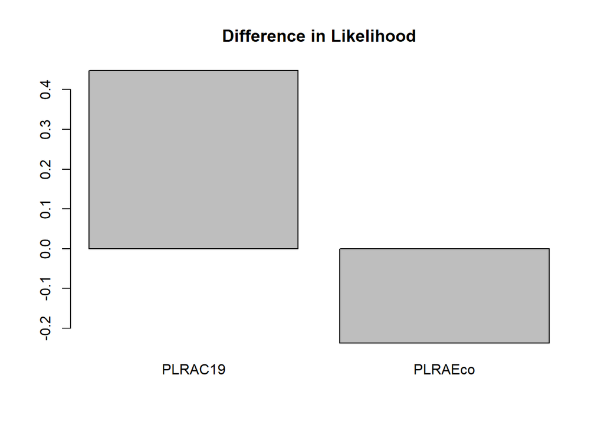

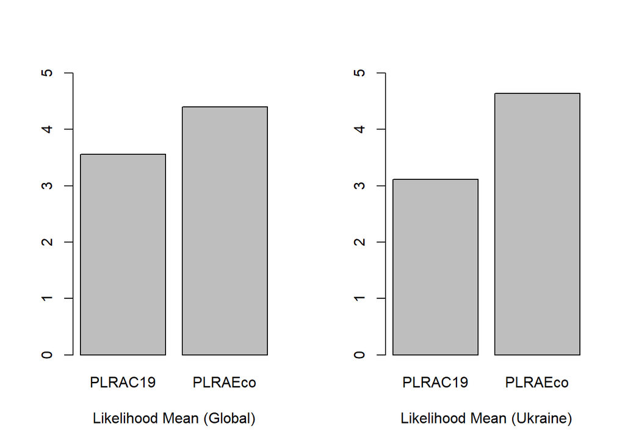

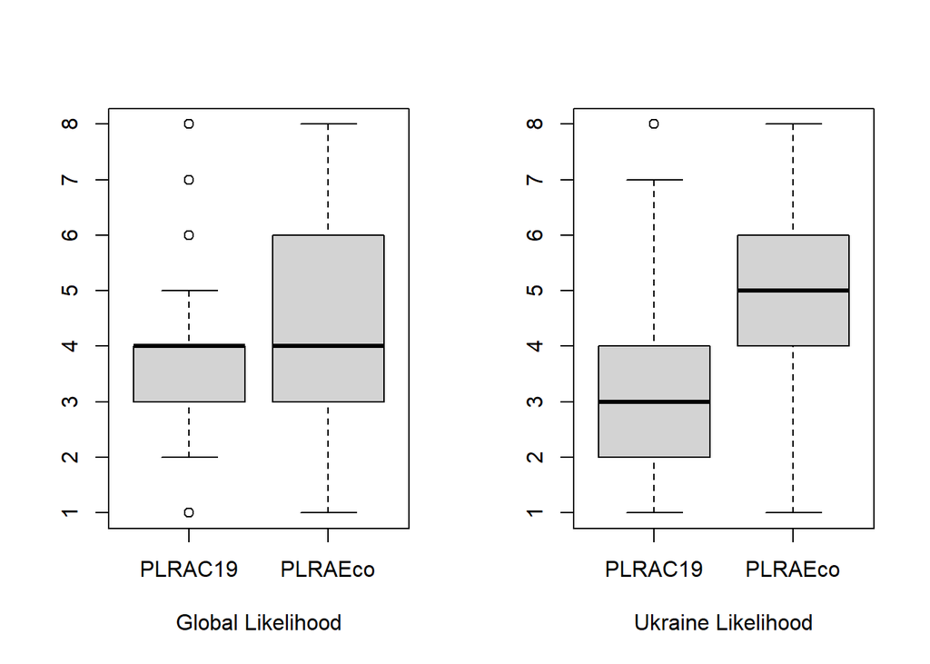

When checking at likelihood statistics. We can see however that Ukrainians are less likely to think that they will be infected with the coronavirus, but think that they are more likely for their personal situation to worsen due to the economic consequences of the coronavirus.

Box and Whisker plots for PLRAEco see a more normal trend with the middle 50% of surveyors at Ukraine being higher than the middle 50% of surveyors globally. The median for Ukraine being higher as well.

Ukrainians seem to not think that they would get COVID-19, but are more likely to think that their personal situation would worsen due to the virus. There seems to form a pattern here that Ukrainians are more sensitive towards their financial health. This may be a key indicator in finding predictors for Pro-Social Behaviors.

For that let’s dive into the Job Insecurity aspect and their financial strain. As in, do Ukrainians agree or disagree about their job security?

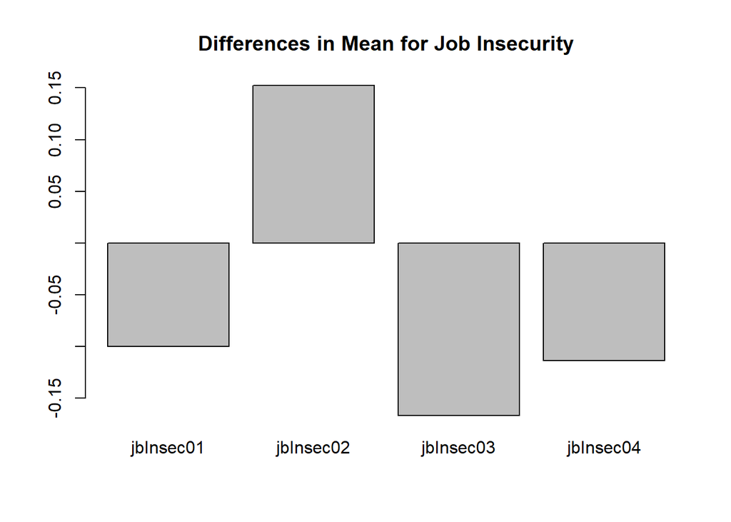

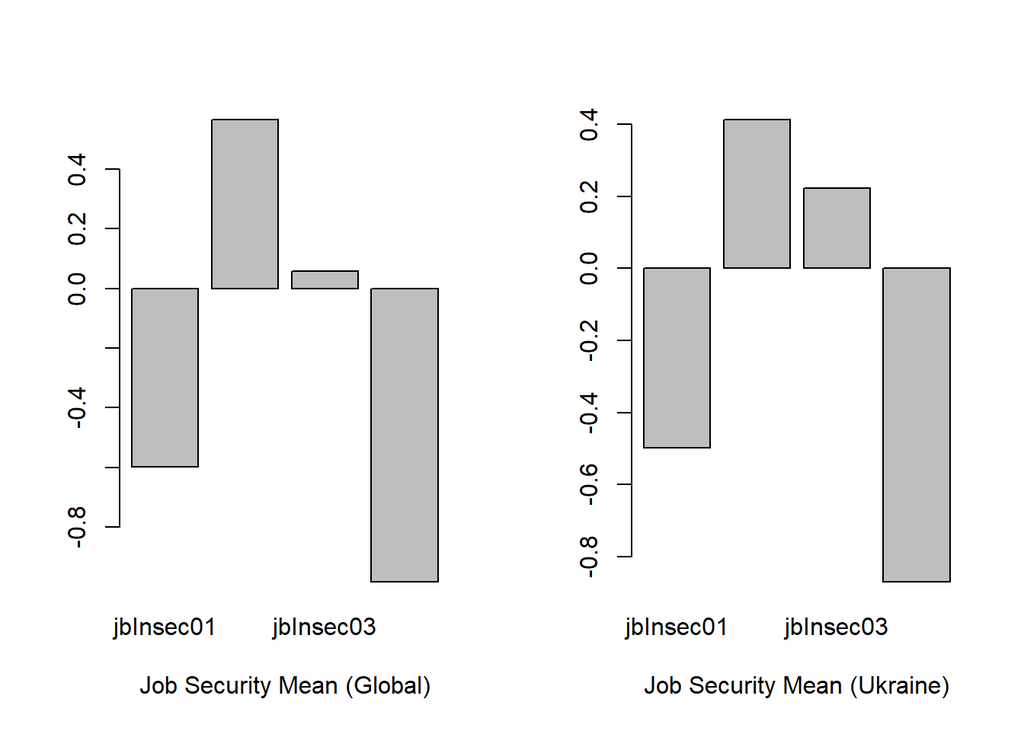

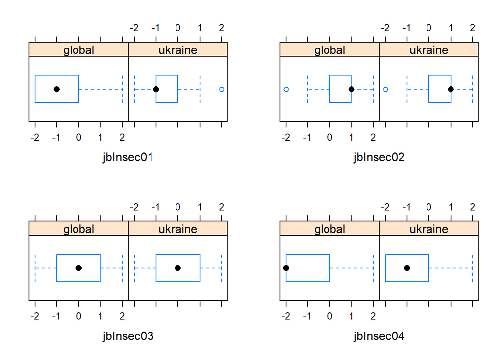

From the data above, Ukrainians believe they are more likely to lose their job soon as jbInsec01 is higher while they are less likely to think that they will keep their job (jbInsec02 is lower). They are also more likely to agree that they are insecure about the future of their job (jbInsec03 is higher) and more of them agree that they have already lost their job (jbInsec04 is higher).

Based on the box and whisker plots that we have gotten here, for the question: “Chances are, I will soon lose my job” (jbInsec01), Ukrainians are more likely to choose between Disagree and Neither agree nor disagree while the global average chooses more between Strongly Disagree and Neither agree nor disagree. However only a small number of Ukrainians stated that they Strongly agree about losing their job, meaning that standard deviation of the opinions of Ukrainians are generally more tightly knitted. This comes to no surprise as they go through a similar situation in their country.

jbInsec02 and jbInsec03 has same statistics for both global and Ukrainian values in their box and whisker plots. jbInsec04’s median on the global statistic is at the lowest value, -2 as compared to -1 for Ukraine.

Let us examine their Perceived Financial Strain (PFS) as well

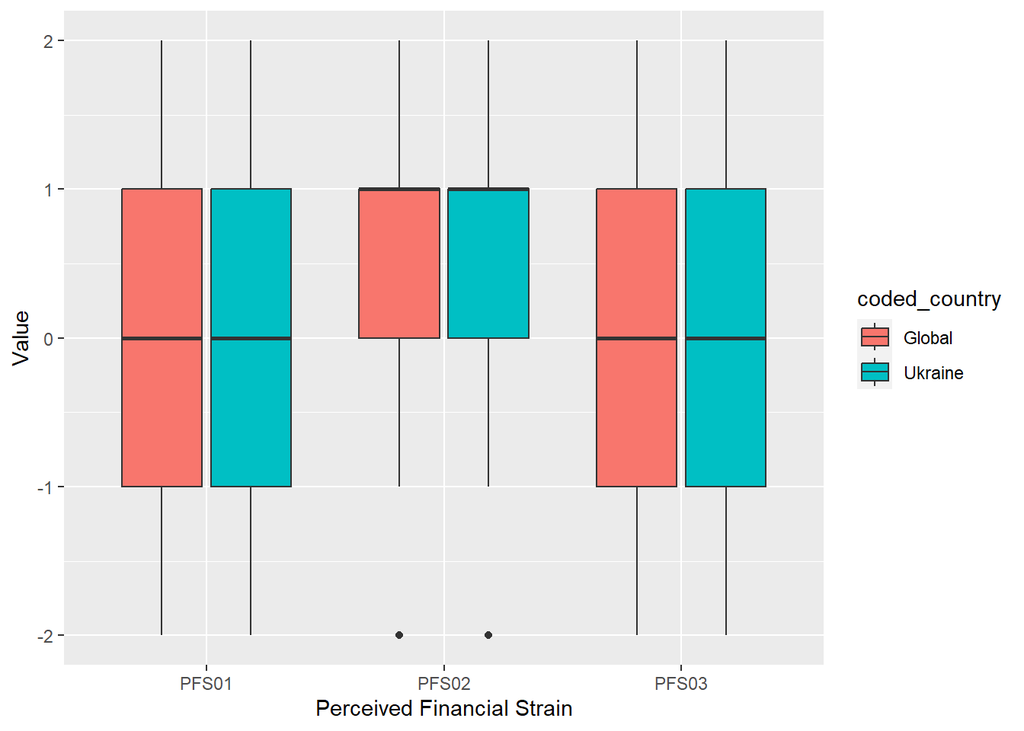

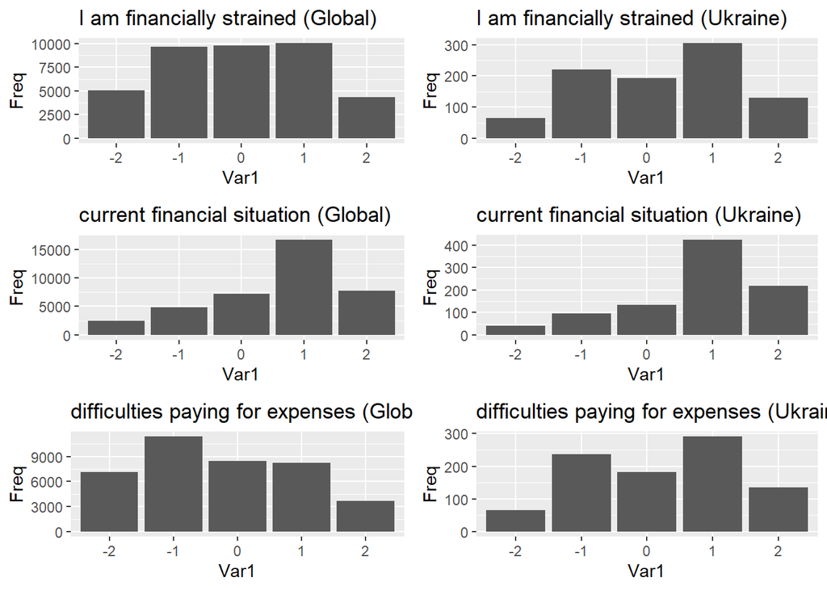

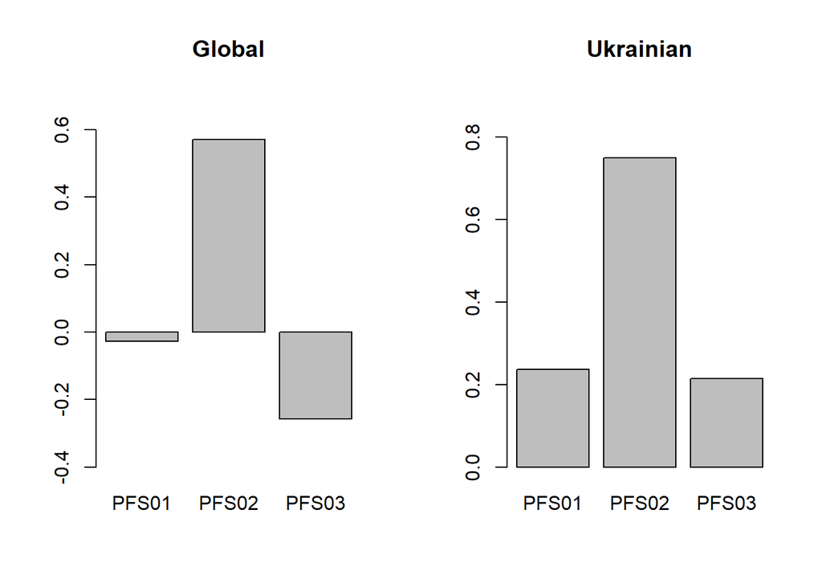

Based on the graphs above. It follows correctly with our previous analysis on Job Insecurity. Ukrainians have higher perceived financial strain. Here they are more likely to agree that they are financially strained (PFS01), that they think more often on their financial situation (PFS02) and that they have difficulties paying for their expenses (PFS03) compared to the global average. Box and Whisker plots show that the distribution however is mostly the same.